# Preterit-Imperfect Appropriate Use Models 9-25-23

# 4: CEDEL2 cross-sectional data

I’m using the repeated subjects data set.

##set-up

```r
#set-up
#going to do the same data cleaning/preparation tasks as I did before

csv_cedel2_duplicates_only <- csv_cedel2_duplicates_only %>%
  mutate(modality = case_when(
    Modality == 'Spoken' ~ -0.5, #imperfect negative
    Modality == 'Written' ~ 0.5 #preterit positive
  ))%>%
  mutate(tense = case_when(
    Corrected_num == 'imperfect' ~ -0.5, #imperfect negative
    Corrected_num == 'preterit' ~ 0.5 #preterit positive
  ))%>%
  mutate(regularity = case_when(
    Regularity == 'I' ~ -0.5, #irregular is -0.5
    Regularity == 'R' ~ 0.5 #regular is 0.5 (positive)
  ))%>%
  mutate(
    #changed 1-16-23 to reflect new data
    frequency = center_scale(csv_cedel2_duplicates_only$log_sum_frq)
  )%>%
  drop_na(regularity)%>% #getting rid of NAs; becomes 356 data points
  mutate(
    infinitive = tolower(Infinitive_no_reflex)
  )
#view(csv_cedel2_duplicates_only)

#separate by tense
csv_cedel2_duplicates_only_pret <- csv_cedel2_duplicates_only%>%
  filter(Corrected_num == 'preterit')

csv_cedel2_duplicates_only_imp <- csv_cedel2_duplicates_only%>%
  filter(Corrected_num == 'imperfect')
```

## show differences in accuracy based on tense

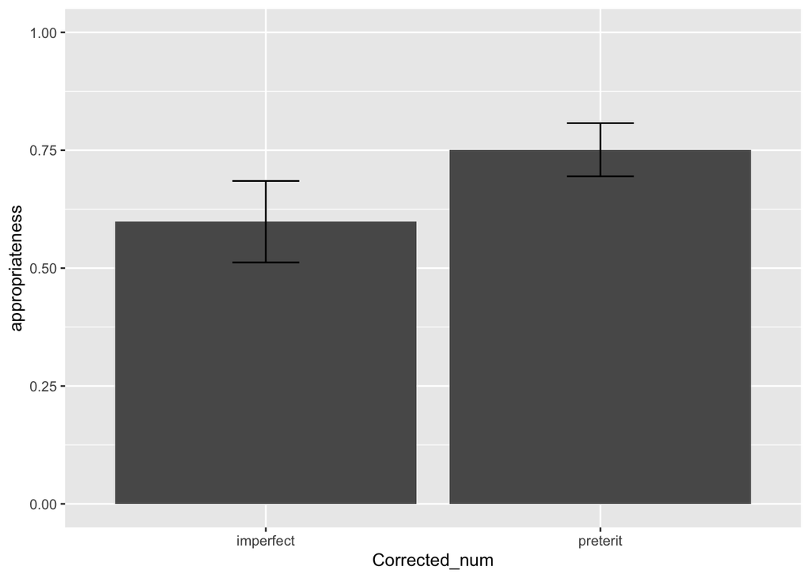

```r
#get error bars
t_summary1 <- summarySE(csv_cedel2_duplicates_only,
                        measurevar="appropriateness",
                        groupvars=c("Corrected_num"))
#view(t_summary1)

# Use 95% confidence intervals instead of SEM
ggplot(t_summary1, aes(x=Corrected_num, y=appropriateness)) +
    geom_bar(position=position_dodge(), stat="identity") +
    geom_errorbar(aes(ymin=appropriateness-ci, ymax=appropriateness+ci),
                  width=.2,                    # Width of the error bars
                  position=position_dodge(.9))+
  ylim(0,1)
```

```r
#no irregular verbs dataset
csv_cedel2_duplicates_only_reg <- csv_cedel2_duplicates_only %>%
  filter(regularity == 0.5)

#view(csv_cedel2_duplicates_only_reg)
#removes about 90 data points
```

# Both tenses together

## Model 0 : apr ~ tense * freq * regularity * modality + (1+tense * freq * regularity * modality||Name) + (1|inf)

```r
model1 <- glmer(appropriateness ~ tense * modality * frequency * regularity +
                  (1+tense * modality * frequency * regularity||Name) + (1|infinitive), csv_cedel2_duplicates_only,
                  family = 'binomial', control = glmerControl(optimizer="bobyqa", optCtrl=list(maxfun=50000)))
```

```
## boundary (singular) fit: see help('isSingular')
```

```r
summary(model1)
```

```
## Generalized linear mixed model fit by maximum likelihood (Laplace
##   Approximation) [glmerMod]
##  Family: binomial  ( logit )
## Formula: appropriateness ~ tense * modality * frequency * regularity +
##     (1 + tense * modality * frequency * regularity || Name) +
##     (1 | infinitive)
##    Data: csv_cedel2_duplicates_only
## Control: glmerControl(optimizer = "bobyqa", optCtrl = list(maxfun = 50000))
##
##      AIC      BIC   logLik deviance df.resid
##    401.8    529.7   -167.9    335.8      323
##
## Scaled residuals:
##     Min      1Q  Median      3Q     Max
## -3.1712 -0.3118  0.1992  0.4479  1.4082
##
## Random effects:
##  Groups     Name                                Variance  Std.Dev.
##  infinitive (Intercept)                         9.948e-01 9.974e-01
##  Name       tense:modality:frequency:regularity 3.289e-13 5.735e-07
##  Name.1     modality:frequency:regularity       1.975e-13 4.444e-07
##  Name.2     tense:frequency:regularity          0.000e+00 0.000e+00
##  Name.3     tense:modality:regularity           1.173e+01 3.425e+00
##  Name.4     tense:modality:frequency            2.319e+01 4.816e+00
##  Name.5     frequency:regularity                0.000e+00 0.000e+00
##  Name.6     modality:regularity                 0.000e+00 0.000e+00
##  Name.7     tense:regularity                    5.083e+00 2.255e+00
##  Name.8     modality:frequency                  0.000e+00 0.000e+00
##  Name.9     tense:frequency                     3.895e+00 1.974e+00
##  Name.10    tense:modality                      0.000e+00 0.000e+00
##  Name.11    regularity                          2.315e+00 1.521e+00
##  Name.12    frequency                           0.000e+00 0.000e+00
##  Name.13    modality                            2.721e-01 5.216e-01
##  Name.14    tense                               0.000e+00 0.000e+00
##  Name.15    (Intercept)                         4.035e-01 6.352e-01
## Number of obs: 356, groups:  infinitive, 57; Name, 11
##
## Fixed effects:
##                                     Estimate Std. Error z value Pr(>|z|)
## (Intercept)                            3.168     15.165   0.209    0.835
## tense                                 -1.073     30.319  -0.035    0.972
## modality                               5.359     30.318   0.177    0.860
## frequency                             -1.035      8.712  -0.119    0.905
## regularity                            -3.262     30.326  -0.108    0.914
## tense:modality                        -5.479     60.624  -0.090    0.928
## tense:frequency                        1.504     17.435   0.086    0.931
## modality:frequency                    -1.673     17.414  -0.096    0.923
## tense:regularity                       5.422     60.638   0.089    0.929
## modality:regularity                   -7.485     60.632  -0.123    0.902
## frequency:regularity                   2.683     17.423   0.154    0.878
## tense:modality:frequency               1.760     34.857   0.050    0.960
## tense:modality:regularity              8.768    121.248   0.072    0.942
## tense:frequency:regularity            -3.099     34.841  -0.089    0.929
## modality:frequency:regularity          2.308     34.828   0.066    0.947
## tense:modality:frequency:regularity   -4.695     69.644  -0.067    0.946
```

```
##
## Correlation matrix not shown by default, as p = 16 > 12.
## Use print(x, correlation=TRUE)  or
##     vcov(x)        if you need it
```

```
## optimizer (bobyqa) convergence code: 0 (OK)
## boundary (singular) fit: see help('isSingular')
```

## Model 0.1 : no 4-way interaction

```r
model1 <- glmer(appropriateness ~ tense + modality + frequency + regularity + tense:modality + tense:frequency + tense:regularity + modality:frequency + modality:regularity + frequency:regularity + tense:modality:frequency + tense:modality:regularity + tense:frequency:regularity + modality:frequency:regularity +
                  (1+tense + modality + frequency + regularity + tense:modality + tense:frequency + tense:regularity + modality:frequency + modality:regularity + frequency:regularity + tense:modality:frequency + tense:modality:regularity + tense:frequency:regularity + modality:frequency:regularity||Name) + (1|infinitive), csv_cedel2_duplicates_only,
                  family = 'binomial', control = glmerControl(optimizer="bobyqa", optCtrl=list(maxfun=50000)))
```

```
## boundary (singular) fit: see help('isSingular')
```

```r
summary(model1)
```

```
## Generalized linear mixed model fit by maximum likelihood (Laplace
##   Approximation) [glmerMod]
##  Family: binomial  ( logit )
## Formula: appropriateness ~ tense + modality + frequency + regularity +
##     tense:modality + tense:frequency + tense:regularity + modality:frequency +
##     modality:regularity + frequency:regularity + tense:modality:frequency +
##     tense:modality:regularity + tense:frequency:regularity +
##     modality:frequency:regularity + (1 + tense + modality + frequency +
##     regularity + tense:modality + tense:frequency + tense:regularity +
##     modality:frequency + modality:regularity + frequency:regularity +
##     tense:modality:frequency + tense:modality:regularity + tense:frequency:regularity +
##     modality:frequency:regularity || Name) + (1 | infinitive)
##    Data: csv_cedel2_duplicates_only
## Control: glmerControl(optimizer = "bobyqa", optCtrl = list(maxfun = 50000))
##
##      AIC      BIC   logLik deviance df.resid
##    397.8    518.0   -167.9    335.8      325
##
## Scaled residuals:
##     Min      1Q  Median      3Q     Max
## -3.1684 -0.3118  0.1992  0.4479  1.4054
##
## Random effects:
##  Groups     Name                          Variance  Std.Dev.
##  infinitive (Intercept)                   9.935e-01 9.968e-01
##  Name       modality:frequency:regularity 3.240e-14 1.800e-07
##  Name.1     tense:frequency:regularity    0.000e+00 0.000e+00
##  Name.2     tense:modality:regularity     1.183e+01 3.439e+00
##  Name.3     tense:modality:frequency      2.324e+01 4.821e+00
##  Name.4     frequency:regularity          0.000e+00 0.000e+00
##  Name.5     modality:regularity           3.441e-10 1.855e-05
##  Name.6     modality:frequency            0.000e+00 0.000e+00
##  Name.7     tense:regularity              5.083e+00 2.254e+00
##  Name.8     tense:frequency               3.909e+00 1.977e+00
##  Name.9     tense:modality                0.000e+00 0.000e+00
##  Name.10    regularity                    2.323e+00 1.524e+00
##  Name.11    frequency                     0.000e+00 0.000e+00
##  Name.12    modality                      2.728e-01 5.223e-01
##  Name.13    tense                         0.000e+00 0.000e+00
##  Name.14    (Intercept)                   4.033e-01 6.350e-01
## Number of obs: 356, groups:  infinitive, 57; Name, 11
##
## Fixed effects:
##                                 Estimate Std. Error z value Pr(>|z|)
## (Intercept)                    2.1642603  0.9085476   2.382   0.0172 *
## tense                          0.9420723  1.4714446   0.640   0.5220
## modality                       3.3449751  1.5346085   2.180   0.0293 *
## frequency                     -0.4605786  0.6481991  -0.711   0.4774
## regularity                    -1.2542629  1.7669520  -0.710   0.4778
## tense:modality                -1.4325226  2.1929933  -0.653   0.5136
## tense:frequency                0.3442356  1.2463190   0.276   0.7824
## tense:regularity               1.3937165  3.1126711   0.448   0.6543
## modality:frequency            -0.5173660  1.0446623  -0.495   0.6204
## modality:regularity           -3.4539998  2.8782243  -1.200   0.2301
## frequency:regularity           1.5359543  1.3471091   1.140   0.2542
## tense:modality:frequency      -0.5761528  2.0327121  -0.283   0.7768
## tense:modality:regularity      0.6743532  4.5510896   0.148   0.8822
## tense:frequency:regularity    -0.7794328  1.9947649  -0.391   0.6960
## modality:frequency:regularity -0.0006023  2.2326814   0.000   0.9998
## ---
## Signif. codes:  0 '***' 0.001 '**' 0.01 '*' 0.05 '.' 0.1 ' ' 1
```

```
##
## Correlation matrix not shown by default, as p = 15 > 12.
## Use print(x, correlation=TRUE)  or
##     vcov(x)        if you need it
```

```
## optimizer (bobyqa) convergence code: 0 (OK)
## boundary (singular) fit: see help('isSingular')
```

## Model 0.2 : no 3-way interactions

```r
model1 <- glmer(appropriateness ~ tense + modality + frequency + regularity + tense:modality + tense:frequency + tense:regularity + modality:frequency + modality:regularity + frequency:regularity  +
                  (1+tense + modality + frequency + regularity + tense:modality + tense:frequency + tense:regularity + modality:frequency + modality:regularity + frequency:regularity||Name) + (1|infinitive), csv_cedel2_duplicates_only,
                  family = 'binomial', control = glmerControl(optimizer="bobyqa", optCtrl=list(maxfun=50000)))
```

```
## boundary (singular) fit: see help('isSingular')
```

```r
summary(model1)
```

```
## Generalized linear mixed model fit by maximum likelihood (Laplace
##   Approximation) [glmerMod]
##  Family: binomial  ( logit )
## Formula: appropriateness ~ tense + modality + frequency + regularity +
##     tense:modality + tense:frequency + tense:regularity + modality:frequency +
##     modality:regularity + frequency:regularity + (1 + tense +
##     modality + frequency + regularity + tense:modality + tense:frequency +
##     tense:regularity + modality:frequency + modality:regularity +
##     frequency:regularity || Name) + (1 | infinitive)
##    Data: csv_cedel2_duplicates_only
## Control: glmerControl(optimizer = "bobyqa", optCtrl = list(maxfun = 50000))
##
##      AIC      BIC   logLik deviance df.resid
##    391.7    480.8   -172.8    345.7      333
##
## Scaled residuals:
##     Min      1Q  Median      3Q     Max
## -3.8269 -0.3330  0.2339  0.4649  1.4095
##
## Random effects:
##  Groups     Name                 Variance Std.Dev.
##  infinitive (Intercept)          1.1759   1.0844
##  Name       frequency:regularity 0.0000   0.0000
##  Name.1     modality:regularity  7.4484   2.7292
##  Name.2     modality:frequency   0.0000   0.0000
##  Name.3     tense:regularity     6.3229   2.5145
##  Name.4     tense:frequency      2.5462   1.5957
##  Name.5     tense:modality       0.9967   0.9984
##  Name.6     regularity           1.3970   1.1819
##  Name.7     frequency            0.1357   0.3684
##  Name.8     modality             1.4312   1.1963
##  Name.9     tense                0.2054   0.4532
##  Name.10    (Intercept)          0.4426   0.6653
## Number of obs: 356, groups:  infinitive, 57; Name, 11
##
## Fixed effects:
##                      Estimate Std. Error z value Pr(>|z|)
## (Intercept)            1.8709     0.5650   3.311 0.000929 ***
## tense                  2.0757     0.8347   2.487 0.012896 *
## modality               3.1373     0.8150   3.850 0.000118 ***
```

[output cut: 21 more lines]

```
## mdlty:rglrt -0.314 -0.078 -0.551  0.186  0.362  0.164 -0.002  0.028  0.293
## frqncy:rglr  0.427 -0.041  0.154 -0.494 -0.327 -0.110  0.204  0.235 -0.161
##             mdlty:r
## tense
## modality
## frequency
## regularity
## tense:mdlty
## tens:frqncy
## tens:rglrty
## mdlty:frqnc
## mdlty:rglrt
## frqncy:rglr -0.172
## optimizer (bobyqa) convergence code: 0 (OK)
## boundary (singular) fit: see help('isSingular')
```

## Model 0.3 : no 3-way interactions, clearing out 2-way interactions

```r
model1 <- glmer(appropriateness ~ tense + modality + frequency + regularity + tense:modality + tense:regularity + modality:frequency + modality:regularity + frequency:regularity  +
                  (1+tense + modality + frequency + regularity + tense:modality + tense:regularity + modality:frequency + modality:regularity + frequency:regularity||Name) + (1|infinitive), csv_cedel2_duplicates_only,
                  family = 'binomial', control = glmerControl(optimizer="bobyqa", optCtrl=list(maxfun=50000)))
```

```
## boundary (singular) fit: see help('isSingular')
```

```r
summary(model1)
```

```
## Generalized linear mixed model fit by maximum likelihood (Laplace
##   Approximation) [glmerMod]
##  Family: binomial  ( logit )
## Formula: appropriateness ~ tense + modality + frequency + regularity +
##     tense:modality + tense:regularity + modality:frequency +
##     modality:regularity + frequency:regularity + (1 + tense +
##     modality + frequency + regularity + tense:modality + tense:regularity +
##     modality:frequency + modality:regularity + frequency:regularity ||
##     Name) + (1 | infinitive)
##    Data: csv_cedel2_duplicates_only
## Control: glmerControl(optimizer = "bobyqa", optCtrl = list(maxfun = 50000))
##
##      AIC      BIC   logLik deviance df.resid
##    394.4    475.7   -176.2    352.4      335
##
## Scaled residuals:
##     Min      1Q  Median      3Q     Max
## -3.4018 -0.3301  0.2666  0.4460  1.3969
##
## Random effects:
##  Groups     Name                 Variance Std.Dev.
##  infinitive (Intercept)          1.5158   1.2312
##  Name       frequency:regularity 0.0000   0.0000
##  Name.1     modality:regularity  6.6874   2.5860
##  Name.2     modality:frequency   0.0000   0.0000
##  Name.3     tense:regularity     6.3361   2.5172
##  Name.4     tense:modality       1.1621   1.0780
##  Name.5     regularity           0.6494   0.8058
##  Name.6     frequency            0.1983   0.4453
##  Name.7     modality             1.4280   1.1950
##  Name.8     tense                0.3173   0.5633
##  Name.9     (Intercept)          0.3720   0.6099
## Number of obs: 356, groups:  infinitive, 57; Name, 11
##
## Fixed effects:
##                      Estimate Std. Error z value Pr(>|z|)
## (Intercept)           1.74800    0.53688   3.256 0.001131 **
## tense                 2.21733    0.83155   2.667 0.007664 **
## modality              3.00642    0.79494   3.782 0.000156 ***
## frequency            -0.09347    0.36963  -0.253 0.800372
## regularity           -0.56135    0.88342  -0.635 0.525149
## tense:modality       -0.40081    0.92266  -0.434 0.663990
## tense:regularity     -1.85017    1.74567  -1.060 0.289207
## modality:frequency   -0.66838    0.42661  -1.567 0.117178
## modality:regularity  -2.81300    1.50556  -1.868 0.061706 .
## frequency:regularity  0.87557    0.63069   1.388 0.165053
## ---
## Signif. codes:  0 '***' 0.001 '**' 0.01 '*' 0.05 '.' 0.1 ' ' 1
##
## Correlation of Fixed Effects:
##             (Intr) tense  modlty frqncy rglrty tns:md tns:rg mdlty:f mdlty:r
## tense        0.004
## modality     0.439  0.249
## frequency   -0.165  0.121 -0.101
## regularity  -0.562  0.262 -0.284  0.368
## tense:mdlty -0.096  0.229 -0.183  0.085  0.146
## tens:rglrty -0.002 -0.582 -0.153 -0.041 -0.242 -0.104
## mdlty:frqnc -0.241 -0.058 -0.311  0.302  0.247  0.285 -0.053
## mdlty:rglrt -0.323 -0.122 -0.542  0.149  0.341  0.168  0.099  0.322
## frqncy:rglr  0.327  0.008  0.139 -0.485 -0.260 -0.100  0.086 -0.250  -0.144
## optimizer (bobyqa) convergence code: 0 (OK)
## boundary (singular) fit: see help('isSingular')
```

## Model 0.4 : no 3-way interactions, clearing out 2-way interactions (tense:modality)

```r
model1 <- glmer(appropriateness ~ tense + modality + frequency + regularity + tense:regularity + modality:frequency + modality:regularity + frequency:regularity  +
                  (1+tense + modality + frequency + regularity  + tense:regularity + modality:frequency + modality:regularity + frequency:regularity||Name) + (1|infinitive), csv_cedel2_duplicates_only,
                  family = 'binomial', control = glmerControl(optimizer="bobyqa", optCtrl=list(maxfun=50000)))
```

```
## boundary (singular) fit: see help('isSingular')
```

```r
summary(model1)
```

```
## Generalized linear mixed model fit by maximum likelihood (Laplace
##   Approximation) [glmerMod]
##  Family: binomial  ( logit )
## Formula: appropriateness ~ tense + modality + frequency + regularity +
##     tense:regularity + modality:frequency + modality:regularity +
##     frequency:regularity + (1 + tense + modality + frequency +
##     regularity + tense:regularity + modality:frequency + modality:regularity +
##     frequency:regularity || Name) + (1 | infinitive)
##    Data: csv_cedel2_duplicates_only
## Control: glmerControl(optimizer = "bobyqa", optCtrl = list(maxfun = 50000))
##
##      AIC      BIC   logLik deviance df.resid
##    390.9    464.5   -176.4    352.9      337
##
## Scaled residuals:
##     Min      1Q  Median      3Q     Max
## -3.6917 -0.3598  0.2642  0.4615  1.4192
##
## Random effects:
##  Groups     Name                 Variance Std.Dev.
##  infinitive (Intercept)          1.5069   1.2276
##  Name       frequency:regularity 0.0000   0.0000
##  Name.1     modality:regularity  7.0961   2.6638
##  Name.2     modality:frequency   0.0000   0.0000
##  Name.3     tense:regularity     6.2410   2.4982
##  Name.4     regularity           0.6514   0.8071
##  Name.5     frequency            0.2084   0.4565
##  Name.6     modality             1.5205   1.2331
##  Name.7     tense                0.4127   0.6424
##  Name.8     (Intercept)          0.3544   0.5953
## Number of obs: 356, groups:  infinitive, 57; Name, 11
##
## Fixed effects:
##                      Estimate Std. Error z value Pr(>|z|)
## (Intercept)           1.71564    0.52652   3.258 0.001120 **
## tense                 2.27106    0.79875   2.843 0.004465 **
## modality              2.89406    0.77378   3.740 0.000184 ***
## frequency            -0.08682    0.36591  -0.237 0.812454
## regularity           -0.54583    0.85683  -0.637 0.524105
## tense:regularity     -1.89905    1.72134  -1.103 0.269923
## modality:frequency   -0.60354    0.39735  -1.519 0.128785
## modality:regularity  -2.67064    1.48943  -1.793 0.072962 .
## frequency:regularity  0.82664    0.62226   1.328 0.184029
## ---
## Signif. codes:  0 '***' 0.001 '**' 0.01 '*' 0.05 '.' 0.1 ' ' 1
##
## Correlation of Fixed Effects:
##             (Intr) tense  modlty frqncy rglrty tns:rg mdlty:f mdlty:r
## tense        0.029
## modality     0.421  0.295
## frequency   -0.151  0.091 -0.083
## regularity  -0.561  0.211 -0.272  0.345
## tens:rglrty -0.015 -0.569 -0.173 -0.024 -0.212
## mdlty:frqnc -0.206 -0.141 -0.252  0.280  0.200 -0.022
## mdlty:rglrt -0.304 -0.175 -0.515  0.123  0.318  0.129  0.264
## frqncy:rglr  0.312  0.028  0.107 -0.480 -0.244  0.078 -0.226  -0.113
## optimizer (bobyqa) convergence code: 0 (OK)
## boundary (singular) fit: see help('isSingular')
```

## Model 0.5 : no 3-way interactions, clearing out 2-way interactions (tense:regularity)

```r
model1 <- glmer(appropriateness ~ tense + modality + frequency + regularity + modality:frequency + modality:regularity + frequency:regularity  +
                  (1+tense + modality + frequency + regularity + modality:frequency + modality:regularity + frequency:regularity||Name) + (1|infinitive), csv_cedel2_duplicates_only,
                  family = 'binomial', control = glmerControl(optimizer="bobyqa", optCtrl=list(maxfun=50000)))
```

```
## boundary (singular) fit: see help('isSingular')
```

```r
summary(model1)
```

```
## Generalized linear mixed model fit by maximum likelihood (Laplace
##   Approximation) [glmerMod]
##  Family: binomial  ( logit )
## Formula: appropriateness ~ tense + modality + frequency + regularity +
##     modality:frequency + modality:regularity + frequency:regularity +
##     (1 + tense + modality + frequency + regularity + modality:frequency +
##         modality:regularity + frequency:regularity || Name) +
##     (1 | infinitive)
##    Data: csv_cedel2_duplicates_only
## Control: glmerControl(optimizer = "bobyqa", optCtrl = list(maxfun = 50000))
##
##      AIC      BIC   logLik deviance df.resid
##    391.9    457.8   -179.0    357.9      339
##
## Scaled residuals:
##     Min      1Q  Median      3Q     Max
## -3.7039 -0.4316  0.2790  0.4851  1.5808
##
## Random effects:
##  Groups     Name                 Variance Std.Dev.
##  infinitive (Intercept)          1.18593  1.0890
##  Name       frequency:regularity 0.07188  0.2681
##  Name.1     modality:regularity  5.82265  2.4130
##  Name.2     modality:frequency   0.00000  0.0000
##  Name.3     regularity           0.79348  0.8908
##  Name.4     frequency            0.15810  0.3976
##  Name.5     modality             1.51975  1.2328
##  Name.6     tense                0.88913  0.9429
##  Name.7     (Intercept)          0.25742  0.5074
## Number of obs: 356, groups:  infinitive, 57; Name, 11
##
## Fixed effects:
##                      Estimate Std. Error z value Pr(>|z|)
## (Intercept)            1.7470     0.4824   3.622 0.000293 ***
## tense                  1.5442     0.6081   2.539 0.011106 *
## modality               2.7802     0.7354   3.780 0.000157 ***
## frequency             -0.1280     0.3427  -0.374 0.708693
## regularity            -0.8881     0.7849  -1.132 0.257825
## modality:frequency    -0.6075     0.3805  -1.597 0.110364
## modality:regularity   -2.5994     1.3967  -1.861 0.062723 .
## frequency:regularity   0.8935     0.5820   1.535 0.124748
## ---
## Signif. codes:  0 '***' 0.001 '**' 0.01 '*' 0.05 '.' 0.1 ' ' 1
##
## Correlation of Fixed Effects:
##             (Intr) tense  modlty frqncy rglrty mdlty:f mdlty:r
## tense        0.026
## modality     0.457  0.192
## frequency   -0.157  0.088 -0.106
## regularity  -0.575  0.063 -0.338  0.340
## mdlty:frqnc -0.209 -0.187 -0.259  0.282  0.199
## mdlty:rglrt -0.353 -0.106 -0.508  0.156  0.389  0.290
## frqncy:rglr  0.277  0.095  0.117 -0.479 -0.211 -0.196  -0.135
## optimizer (bobyqa) convergence code: 0 (OK)
## boundary (singular) fit: see help('isSingular')
```

## Model 0.6 : no 3-way interactions, clearing out 2-way interactions (modality:frequency)

```r
model1 <- glmer(appropriateness ~ tense + modality + frequency + regularity + modality:regularity + frequency:regularity  +
                  (1+tense + modality + frequency + regularity + modality:regularity + frequency:regularity||Name) + (1|infinitive), csv_cedel2_duplicates_only,
                  family = 'binomial', control = glmerControl(optimizer="bobyqa", optCtrl=list(maxfun=50000)))

summary(model1)
```

```
## Generalized linear mixed model fit by maximum likelihood (Laplace
##   Approximation) [glmerMod]
##  Family: binomial  ( logit )
## Formula: appropriateness ~ tense + modality + frequency + regularity +
##     modality:regularity + frequency:regularity + (1 + tense +
##     modality + frequency + regularity + modality:regularity +
##     frequency:regularity || Name) + (1 | infinitive)
##    Data: csv_cedel2_duplicates_only
## Control: glmerControl(optimizer = "bobyqa", optCtrl = list(maxfun = 50000))
##
##      AIC      BIC   logLik deviance df.resid
##    390.6    448.7   -180.3    360.6      341
##
## Scaled residuals:
##     Min      1Q  Median      3Q     Max
## -3.6277 -0.4912  0.2823  0.4920  1.5503
##
## Random effects:
##  Groups     Name                 Variance Std.Dev.
##  infinitive (Intercept)          1.07087  1.0348
##  Name       frequency:regularity 0.04246  0.2061
##  Name.1     modality:regularity  4.09667  2.0240
##  Name.2     regularity           1.02485  1.0123
##  Name.3     frequency            0.15755  0.3969
##  Name.4     modality             1.41345  1.1889
##  Name.5     tense                0.73542  0.8576
##  Name.6     (Intercept)          0.30634  0.5535
## Number of obs: 356, groups:  infinitive, 57; Name, 11
##
## Fixed effects:
##                      Estimate Std. Error z value Pr(>|z|)
## (Intercept)           1.65353    0.46076   3.589 0.000332 ***
## tense                 1.39506    0.56622   2.464 0.013747 *
## modality              2.56920    0.68866   3.731 0.000191 ***
## frequency             0.02356    0.32161   0.073 0.941593
## regularity           -0.69121    0.75488  -0.916 0.359848
## modality:regularity  -2.03429    1.24998  -1.627 0.103641
## frequency:regularity  0.71919    0.55359   1.299 0.193895
## ---
## Signif. codes:  0 '***' 0.001 '**' 0.01 '*' 0.05 '.' 0.1 ' ' 1
##
## Correlation of Fixed Effects:
##             (Intr) tense  modlty frqncy rglrty mdlty:
## tense       -0.012
## modality     0.409  0.152
## frequency   -0.075  0.152 -0.002
## regularity  -0.522  0.092 -0.276  0.269
## mdlty:rglrt -0.312 -0.068 -0.487  0.059  0.348
## frqncy:rglr  0.214  0.047  0.037 -0.460 -0.143 -0.048
```

## Model 0.7 : no 3-way interactions, clearing out 2-way interactions (frequency:regularity)

```r
model1 <- glmer(appropriateness ~ tense + modality + frequency + regularity + modality:regularity +
                  (1+tense + modality + frequency + regularity + modality:regularity ||Name) + (1|infinitive), csv_cedel2_duplicates_only,
                  family = 'binomial', control = glmerControl(optimizer="bobyqa", optCtrl=list(maxfun=50000)))

summary(model1)
```

```
## Generalized linear mixed model fit by maximum likelihood (Laplace
##   Approximation) [glmerMod]
##  Family: binomial  ( logit )
## Formula: appropriateness ~ tense + modality + frequency + regularity +
##     modality:regularity + (1 + tense + modality + frequency +
##     regularity + modality:regularity || Name) + (1 | infinitive)
##    Data: csv_cedel2_duplicates_only
## Control: glmerControl(optimizer = "bobyqa", optCtrl = list(maxfun = 50000))
##
##      AIC      BIC   logLik deviance df.resid
##    388.2    438.6   -181.1    362.2      343
##
## Scaled residuals:
##     Min      1Q  Median      3Q     Max
## -4.0598 -0.4836  0.2645  0.4916  1.3142
##
## Random effects:
##  Groups     Name                Variance Std.Dev.
##  infinitive (Intercept)         1.3558   1.1644
##  Name       modality:regularity 4.2290   2.0565
##  Name.1     regularity          1.1501   1.0724
##  Name.2     frequency           0.2141   0.4627
##  Name.3     modality            1.6651   1.2904
##  Name.4     tense               0.8810   0.9386
##  Name.5     (Intercept)         0.3047   0.5520
## Number of obs: 356, groups:  infinitive, 57; Name, 11
##
## Fixed effects:
##                     Estimate Std. Error z value Pr(>|z|)
## (Intercept)           1.6015     0.4705   3.404 0.000665 ***
## tense                 1.3963     0.5952   2.346 0.018987 *
## modality              2.6169     0.7077   3.698 0.000217 ***
## frequency             0.2139     0.3031   0.706 0.480338
## regularity           -0.6455     0.7765  -0.831 0.405838
## modality:regularity  -2.0675     1.2538  -1.649 0.099156 .
## ---
## Signif. codes:  0 '***' 0.001 '**' 0.01 '*' 0.05 '.' 0.1 ' ' 1
##
## Correlation of Fixed Effects:
##             (Intr) tense  modlty frqncy rglrty
## tense       -0.041
## modality     0.385  0.145
## frequency    0.079  0.191  0.051
## regularity  -0.508  0.102 -0.254  0.181
## mdlty:rglrt -0.287 -0.073 -0.463 -0.013  0.321
```

#in paper currently

## *Model 0.7.1 : no 3-way or 2-way interactions

```r
model1 <- glmer(appropriateness ~ tense + modality + frequency + regularity +
                  (1+tense + modality + frequency + regularity ||Name) + (1|infinitive), csv_cedel2_duplicates_only,
                  family = 'binomial', control = glmerControl(optimizer="bobyqa", optCtrl=list(maxfun=50000)))

summary(model1)
```

```
## Generalized linear mixed model fit by maximum likelihood (Laplace
##   Approximation) [glmerMod]
##  Family: binomial  ( logit )
## Formula: appropriateness ~ tense + modality + frequency + regularity +
##     (1 + tense + modality + frequency + regularity || Name) +
##     (1 | infinitive)
##    Data: csv_cedel2_duplicates_only
## Control: glmerControl(optimizer = "bobyqa", optCtrl = list(maxfun = 50000))
##
##      AIC      BIC   logLik deviance df.resid
##    389.4    432.0   -183.7    367.4      345
##
## Scaled residuals:
##     Min      1Q  Median      3Q     Max
## -4.3064 -0.5367  0.2948  0.5102  1.6065
##
## Random effects:
##  Groups     Name        Variance Std.Dev.
##  infinitive (Intercept) 1.1878   1.0899
##  Name       regularity  1.3707   1.1708
##  Name.1     frequency   0.1848   0.4298
##  Name.2     modality    1.1806   1.0866
##  Name.3     tense       0.5018   0.7084
##  Name.4     (Intercept) 0.2660   0.5158
## Number of obs: 356, groups:  infinitive, 57; Name, 11
##
## Fixed effects:
##             Estimate Std. Error z value Pr(>|z|)
## (Intercept)   1.3879     0.4164   3.333 0.000859 ***
## tense         1.3298     0.5224   2.545 0.010917 *
## modality      1.9999     0.5318   3.760 0.000170 ***
## frequency     0.2308     0.2806   0.823 0.410771
## regularity   -0.1481     0.7066  -0.210 0.834005
## ---
## Signif. codes:  0 '***' 0.001 '**' 0.01 '*' 0.05 '.' 0.1 ' ' 1
##
## Correlation of Fixed Effects:
##            (Intr) tense  modlty frqncy
## tense      -0.090
## modality    0.260  0.124
## frequency   0.080  0.181  0.060
## regularity -0.414  0.143 -0.033  0.186
```

With categorical tense and modality

```r
model1_092923 <- glmer(appropriateness ~ Corrected_num + Modality + frequency + regularity +
                  (1+Corrected_num + Modality + frequency + regularity ||Name) + (1|infinitive), csv_cedel2_duplicates_only,
                  family = 'binomial', control = glmerControl(optimizer="bobyqa", optCtrl=list(maxfun=50000)))
summary(model1_092923)
```

```
## Generalized linear mixed model fit by maximum likelihood (Laplace
##   Approximation) [glmerMod]
##  Family: binomial  ( logit )
## Formula: appropriateness ~ Corrected_num + Modality + frequency + regularity +
##     (1 + Corrected_num + Modality + frequency + regularity ||
##         Name) + (1 | infinitive)
##    Data: csv_cedel2_duplicates_only
## Control: glmerControl(optimizer = "bobyqa", optCtrl = list(maxfun = 50000))
##
##      AIC      BIC   logLik deviance df.resid
##    396.3    454.4   -183.1    366.3      341
##
## Scaled residuals:
##     Min      1Q  Median      3Q     Max
## -4.0733 -0.5188  0.2842  0.4966  1.6329
##
## Random effects:
##  Groups     Name                   Variance Std.Dev. Corr
##  infinitive (Intercept)            1.245743 1.11613
##  Name       regularity             1.366884 1.16914
##  Name.1     frequency              0.120492 0.34712
##  Name.2     ModalitySpoken         0.354807 0.59566
##             ModalityWritten        0.938505 0.96876  -0.29
##  Name.3     Corrected_numimperfect 0.687960 0.82943
##             Corrected_numpreterit  0.002722 0.05217  0.21
##  Name.4     (Intercept)            0.023374 0.15289
## Number of obs: 356, groups:  infinitive, 57; Name, 11
##
## Fixed effects:
##                       Estimate Std. Error z value Pr(>|z|)
## (Intercept)            -0.3199     0.5948  -0.538 0.590681
## Corrected_numpreterit   1.3699     0.5551   2.468 0.013587 *
## ModalityWritten         2.0408     0.5943   3.434 0.000594 ***
## frequency               0.2313     0.2679   0.863 0.387909
## regularity             -0.1671     0.7160  -0.233 0.815511
## ---
## Signif. codes:  0 '***' 0.001 '**' 0.01 '*' 0.05 '.' 0.1 ' ' 1
##
## Correlation of Fixed Effects:
##             (Intr) Crrct_ MdltyW frqncy
## Crrctd_nmpr -0.716
## ModltyWrttn -0.296  0.134
## frequency   -0.066  0.190  0.074
## regularity  -0.357  0.147 -0.022  0.205
## optimizer (bobyqa) convergence code: 0 (OK)
## unable to evaluate scaled gradient
## Model failed to converge: degenerate  Hessian with 2 negative eigenvalues
```

# R^2 values

```r
r.squaredGLMM(model1)
```

```
##                   R2m       R2c
## theoretical 0.1969621 0.5357986
## delta       0.1635943 0.4450277
```

```r
#                 R2m       R2c
# delta       0.1635943 0.4450277
#reporting delta because based on actual observations

# theoretical 0.1969621 0.5357987
```

#Cohen’s d

```r
#get cohen's d
#divide into groups by tense
#calculate Cohen's d
cohen.d(csv_cedel2_duplicates_only_pret$appropriateness, csv_cedel2_duplicates_only_imp$appropriateness)
```

```
##
## Cohen's d
##
## d estimate: 0.3354277 (small)
## 95 percent confidence interval:
##     lower     upper
## 0.1164367 0.5544186
```

```r
#0.3354277 (small) according to P&O 2014

#effect size by modality?
written <- csv_cedel2_duplicates_only %>%
  filter(Modality == 'Written')

spoken <- csv_cedel2_duplicates_only %>%
  filter(Modality == 'Spoken')
#view(csv_cedel2_duplicates_only)

cohen.d(written$appropriateness, spoken$appropriateness)
```

```
##
## Cohen's d
##
## d estimate: 0.6055081 (medium)
## 95 percent confidence interval:
##     lower     upper
## 0.3887185 0.8222977
```

```r
#0.6055081 (medium)
```

##### Effect plot

Modality

```
## Confidence intervals for merMod models is an experimental feature. The
## intervals reflect only the variance of the fixed effects, not the random
## effects.
```

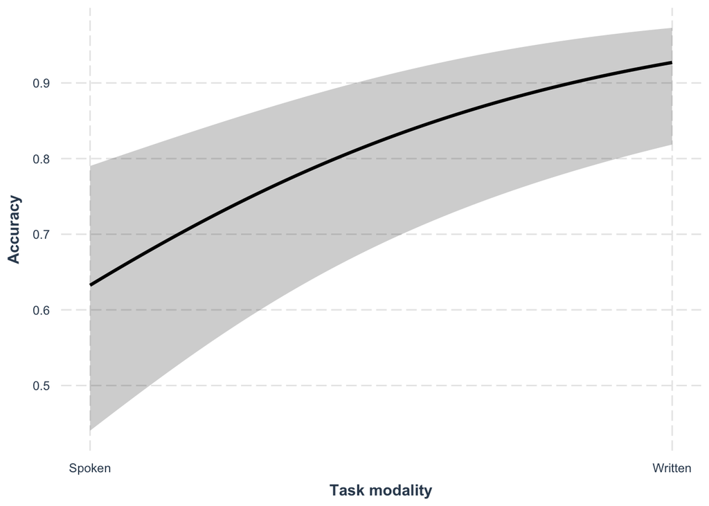

```r
#for modality
effect_plot(model1, pred = modality,
            x.label = 'Task modality',
            y.label = 'Accuracy',
            pred.labels = c('Spoken', 'Written'),
            interval = TRUE)
```

Modality – categorical

```
## Confidence intervals for merMod models is an experimental feature. The
## intervals reflect only the variance of the fixed effects, not the random
## effects.
```

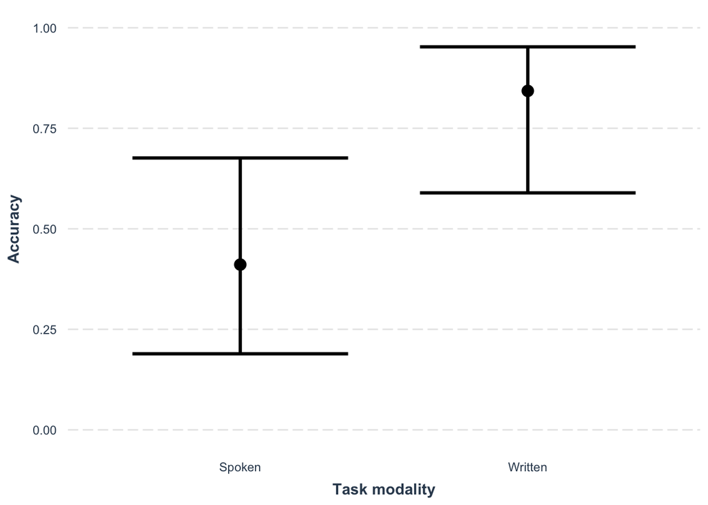

```r
#for modality
effect_plot(model1_092923, pred = Modality,
            x.label = 'Task modality',
            y.label = 'Accuracy',
            #pred.labels = c('Spoken', 'Written'),
            interval = TRUE)+
  ylim(0, 1.0)
```

Tense

```
## Confidence intervals for merMod models is an experimental feature. The
## intervals reflect only the variance of the fixed effects, not the random
## effects.
```

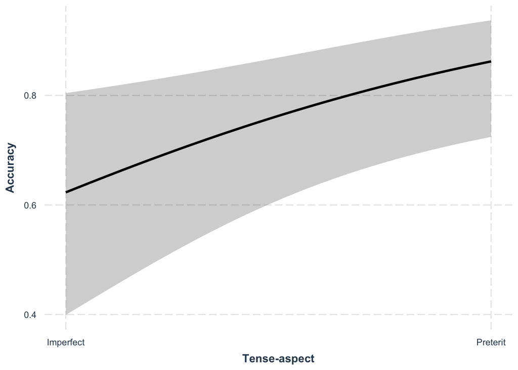

```r
#for tense
effect_plot(model1, pred = tense,
            x.label = 'Tense-aspect',
            y.label = 'Accuracy',
            pred.labels = c('Imperfect', 'Preterit'),
            interval = TRUE)
```

Tense– categorical

```
## Confidence intervals for merMod models is an experimental feature. The
## intervals reflect only the variance of the fixed effects, not the random
## effects.
```

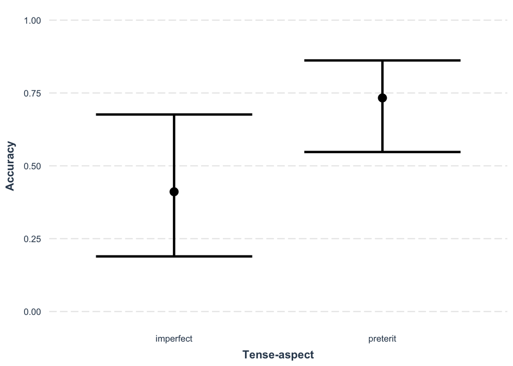

```r
#for tense
effect_plot(model1_092923, pred = Corrected_num,
            x.label = 'Tense-aspect',
            y.label = 'Accuracy',
            pred.labels = c('Imperfect', 'Preterit'),
            interval = TRUE)+
  ylim(0, 1.0)
```

##What about if we took out regularity?

##In paper as a footnote.

```r
model1 <- glmer(appropriateness ~ tense + modality + frequency +
                  (1+tense + modality + frequency ||Name) + (1|infinitive), csv_cedel2_duplicates_only,
                  family = 'binomial', control = glmerControl(optimizer="bobyqa", optCtrl=list(maxfun=50000)))

summary(model1)
```

```
## Generalized linear mixed model fit by maximum likelihood (Laplace
##   Approximation) [glmerMod]
##  Family: binomial  ( logit )
## Formula: appropriateness ~ tense + modality + frequency + (1 + tense +
##     modality + frequency || Name) + (1 | infinitive)
##    Data: csv_cedel2_duplicates_only
## Control: glmerControl(optimizer = "bobyqa", optCtrl = list(maxfun = 50000))
##
##      AIC      BIC   logLik deviance df.resid
##    389.0    423.8   -185.5    371.0      347
##
## Scaled residuals:
##     Min      1Q  Median      3Q     Max
## -3.2376 -0.5847  0.3057  0.5363  1.7407
##
## Random effects:
##  Groups     Name        Variance Std.Dev.
##  infinitive (Intercept) 0.8980   0.9477
##  Name       frequency   0.2264   0.4758
##  Name.1     modality    0.8867   0.9416
##  Name.2     tense       0.1595   0.3994
##  Name.3     (Intercept) 0.2286   0.4782
## Number of obs: 356, groups:  infinitive, 57; Name, 11
##
## Fixed effects:
##             Estimate Std. Error z value Pr(>|z|)
## (Intercept)   1.2376     0.3243   3.816 0.000136 ***
## tense         1.3111     0.4407   2.975 0.002928 **
## modality      1.8458     0.4771   3.869 0.000109 ***
## frequency     0.1847     0.2663   0.694 0.487812
## ---
## Signif. codes:  0 '***' 0.001 '**' 0.01 '*' 0.05 '.' 0.1 ' ' 1
##
## Correlation of Fixed Effects:
##           (Intr) tense  modlty
## tense     -0.012
## modality   0.264  0.142
## frequency  0.165  0.143  0.046
```

```r
r.squaredGLMM(model1)
```

```
##                   R2m       R2c
## theoretical 0.1988340 0.4625197
## delta       0.1608475 0.3741568
```

```r
#                 R2m       R2c
#delta       0.1608475 0.3741570
```

## Model 1.5.1 : apr ~ modality + frequency + (1+modality+frequency||Name) + (1|inf)

```r
model5 <- glmer(appropriateness ~ modality + frequency +
                  (1+modality+frequency||Name) + (1|infinitive), csv_cedel2_duplicates_only_pret,
                  family = 'binomial', control = glmerControl(optimizer="bobyqa", optCtrl=list(maxfun=50000)))


summary(model5)
```

```
## Generalized linear mixed model fit by maximum likelihood (Laplace
##   Approximation) [glmerMod]
##  Family: binomial  ( logit )
## Formula: appropriateness ~ modality + frequency + (1 + modality + frequency ||
##     Name) + (1 | infinitive)
##    Data: csv_cedel2_duplicates_only_pret
## Control: glmerControl(optimizer = "bobyqa", optCtrl = list(maxfun = 50000))
##
##      AIC      BIC   logLik deviance df.resid
##    233.4    257.4   -109.7    219.4      222
##
## Scaled residuals:
##     Min      1Q  Median      3Q     Max
## -3.5429  0.0703  0.2453  0.4669  1.8577
##
## Random effects:
##  Groups     Name        Variance Std.Dev.
##  infinitive (Intercept) 1.4518   1.2049
##  Name       frequency   0.7992   0.8940
##  Name.1     modality    1.7548   1.3247
##  Name.2     (Intercept) 0.5269   0.7259
## Number of obs: 229, groups:  infinitive, 49; Name, 11
##
## Fixed effects:
##             Estimate Std. Error z value Pr(>|z|)
## (Intercept)   2.2412     0.5673   3.951  7.8e-05 ***
## modality      2.0897     0.7189   2.907  0.00365 **
## frequency     0.1578     0.4914   0.321  0.74807
## ---
## Signif. codes:  0 '***' 0.001 '**' 0.01 '*' 0.05 '.' 0.1 ' ' 1
##
## Correlation of Fixed Effects:
##           (Intr) modlty
## modality  0.396
## frequency 0.230  0.024
```

```r
r.squaredGLMM(model5)
```

```
##                   R2m       R2c
## theoretical 0.1494947 0.5552388
## delta       0.1176934 0.4371256
```

```r
#delta       0.1176934 0.4371256
```

STill only effect of modality.

```r
model3 <- glmer(appropriateness ~ frequency +
                  (1+frequency||Name) + (1|infinitive), csv_cedel2_duplicates_only_imp,
                  family = 'binomial', control = glmerControl(optimizer="bobyqa", optCtrl=list(maxfun=50000)))

summary(model3)
```

```
## Generalized linear mixed model fit by maximum likelihood (Laplace
##   Approximation) [glmerMod]
##  Family: binomial  ( logit )
## Formula: appropriateness ~ frequency + (1 + frequency || Name) + (1 |
##     infinitive)
##    Data: csv_cedel2_duplicates_only_imp
## Control: glmerControl(optimizer = "bobyqa", optCtrl = list(maxfun = 50000))
##
##      AIC      BIC   logLik deviance df.resid
##    162.6    176.8    -76.3    152.6      122
##
## Scaled residuals:
##     Min      1Q  Median      3Q     Max
## -3.9264 -0.6161  0.2921  0.6028  1.4522
##
## Random effects:
##  Groups     Name        Variance Std.Dev.
##  infinitive (Intercept) 1.5188   1.2324
##  Name       frequency   0.5706   0.7554
##  Name.1     (Intercept) 0.4804   0.6931
## Number of obs: 127, groups:  infinitive, 21; Name, 10
##
## Fixed effects:
##             Estimate Std. Error z value Pr(>|z|)
## (Intercept)   0.2441     0.4818   0.507    0.612
## frequency    -0.2634     0.4400  -0.599    0.549
##
## Correlation of Fixed Effects:
##           (Intr)
## frequency -0.037
```

Thanks for reading! :)